# 4355hw7

Courtney Schaller

4/27/2021

```r
football <- read.csv("https://raw.githubusercontent.com/schourtney/stat4355/main/football.csv")
football <- football %>% rename(team = 1)
lm <- lm(data = football, y ~ x2 + x7 + x8)
summary(lm)
```

```
##
## Call:
## lm(formula = y ~ x2 + x7 + x8, data = football)
##
## Residuals:
##     Min      1Q  Median      3Q     Max
## -3.0370 -0.7129 -0.2043  1.1101  3.7049
##
## Coefficients:
##              Estimate Std. Error t value Pr(>|t|)
## (Intercept) -1.808372   7.900859  -0.229 0.820899
## x2           0.003598   0.000695   5.177 2.66e-05 ***
## x7           0.193960   0.088233   2.198 0.037815 *
## x8          -0.004816   0.001277  -3.771 0.000938 ***
## ---
## Signif. codes:  0 '***' 0.001 '**' 0.01 '*' 0.05 '.' 0.1 ' ' 1
##
## Residual standard error: 1.706 on 24 degrees of freedom
## Multiple R-squared:  0.7863, Adjusted R-squared:  0.7596
## F-statistic: 29.44 on 3 and 24 DF,  p-value: 3.273e-08
```

1. Perform a thorough residual analysis. (30 points)
1. List the standardized residuals, the studentized residuals and the R-student residuals for this model. (10 points)

```r
football$standres <- stdres(lm)
football$studres <- studres(lm)
football$rstudres <- rstudent(lm)
dfbetas <- as.data.frame(dfbeta(lm)) %>% rename(dfx0 = "(Intercept)", dfx2 = x2, dfx7 = x7, dfx8 = x8)
football <- cbind(football, dfbetas)

minifb <- football %>% dplyr::select(team, standres, studres, rstudres)
kable(minifb)
```

| team | standres | studres | rstudres |
| --- | --- | --- | --- |
| Washington | 2.2318516 | 2.4543542 | 2.4543542 |
| Minnesota | 1.2256164 | 1.2392183 | 1.2392183 |
| New England | 1.7026253 | 1.7775867 | 1.7775867 |
| Oakland | 1.0297678 | 1.0311231 | 1.0311231 |
| Pittsburgh | 0.0061245 | 0.0059955 | 0.0059955 |
| Baltimore | -0.4188762 | -0.4115640 | -0.4115640 |
| Los Angeles | -1.2068370 | -1.2189936 | -1.2189936 |
| Dallas | 0.2993285 | 0.2935746 | 0.2935746 |
| Atlanta | 1.3380323 | 1.3616311 | 1.3616311 |
| Buffalo | -1.4417606 | -1.4768067 | -1.4768067 |
| Chicago | -0.0364685 | -0.0357016 | -0.0357016 |
| Cincinnati | 1.2510901 | 1.2667522 | 1.2667522 |
| Cleveland | -0.0838517 | -0.0820982 | -0.0820982 |
| Denver | -0.1606688 | -0.1573706 | -0.1573706 |
| Detroit | -1.3353673 | -1.3587013 | -1.3587013 |
| Green Bay | 0.6449901 | 0.6369544 | 0.6369544 |
| Houston | -0.1969374 | -0.1929468 | -0.1929468 |
| Kansas City | -0.3650117 | -0.3583224 | -0.3583224 |
| Miami | -0.0789983 | -0.0773451 | -0.0773451 |
| New Orleans | -0.2064643 | -0.2022970 | -0.2022970 |
| New York Giants | -1.8699401 | -1.9805211 | -1.9805211 |
| New York Jets | 0.8172741 | 0.8114375 | 0.8114375 |
| Philadelphia | -0.5510565 | -0.5428995 | -0.5428995 |
| St. Louis | -0.2765447 | -0.2711544 | -0.2711544 |
| San Diego | -1.0185861 | -1.0194179 | -1.0194179 |
| San Francisco | -0.0940558 | -0.0920924 | -0.0920924 |
| Seattle | -0.2621302 | -0.2569792 | -0.2569792 |
| Tampa Bay | -1.0487468 | -1.0510311 | -1.0510311 |

2. Plot the bar graphs of the three types of the scaled residuals. (15 points)

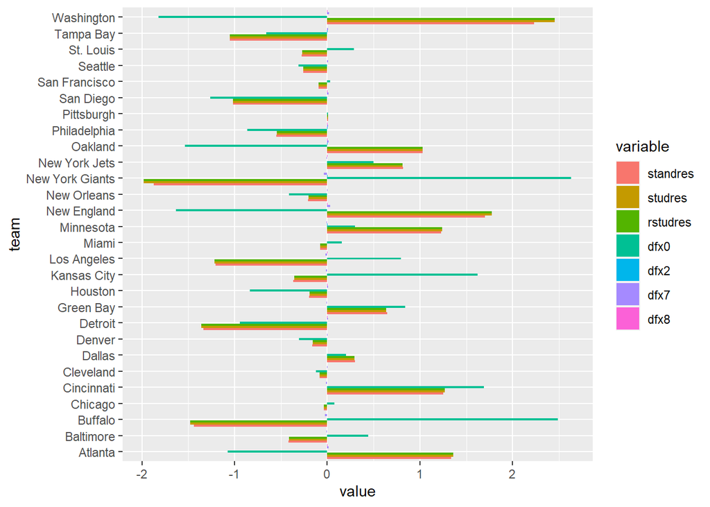

```r
football_reshape <- football %>% melt(id = c("team", "y", "x1", "x2", "x3", "x4", "x5", "x6", "x7", "x8", "x9"))

football_reshape %>% ggplot(aes(x = team, y = value, fill = variable)) + geom_bar(stat = "identity", position = "dodge") + coord_flip()
```

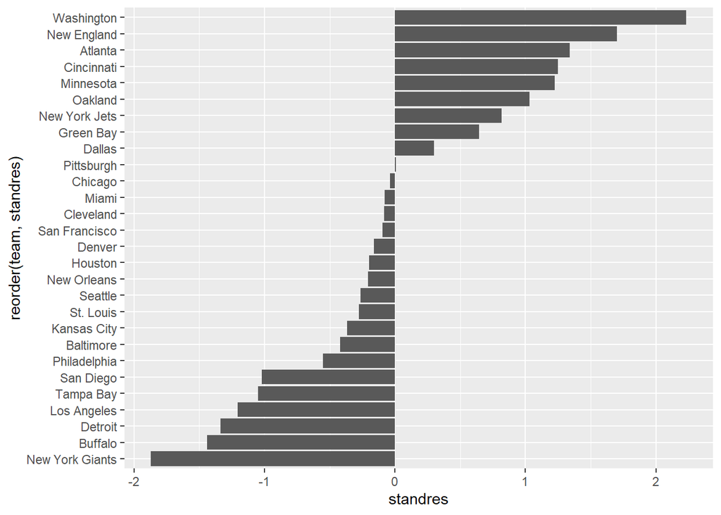

```r
football %>% ggplot(aes(x = reorder(team, standres), y = standres)) + geom_bar(stat = "identity") + coord_flip()
```

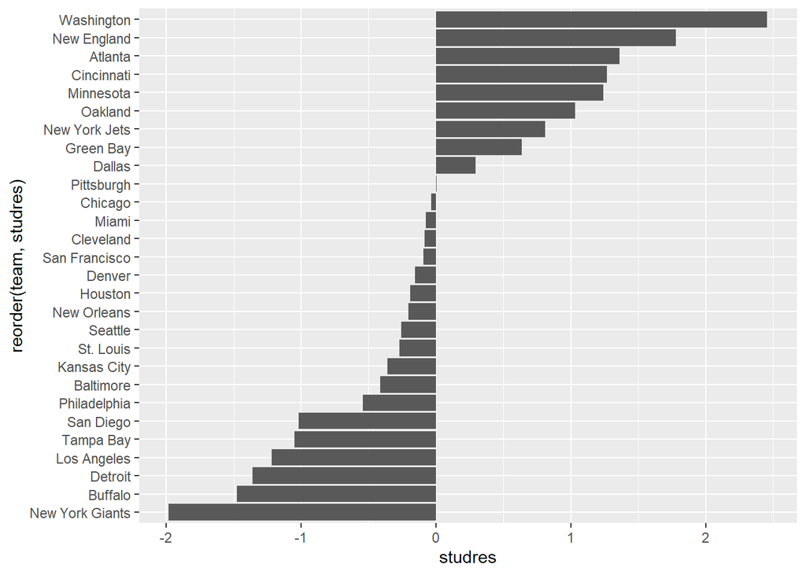

```r
football %>% ggplot(aes(x = reorder(team, studres), y = studres)) + geom_bar(stat = "identity") + coord_flip()
```

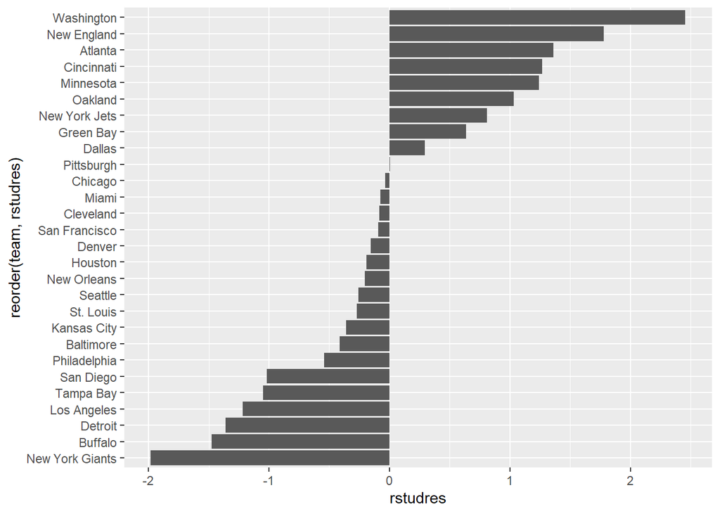

```r
football %>% ggplot(aes(x = reorder(team, rstudres), y = rstudres)) + geom_bar(stat = "identity") + coord_flip()
```

3. What information is conveyed by them? (5 points) We have standardized our residuals by the standard deviation of our residuals to better compare them. The scaled residuals all appear to be approximately standard normal-distributed. This means that our residuals between our predicted and actual y-values are centered around zero, and are normally distributed with standard deviation 1. This means we don’t have any extreme outliers, and it also shows us the points for which the model very accurately predicted (res ~ 0), and those for which the model did not predict very accurately (|res| > 2)
2. Perform a thorough influence analysis. (30 points)
1. List potential influential points suggested by the hat values, Cook’s D, DFBETAS, DFFITS, and COVRATIO. (10 points)

2. Plot the graphs of the hat values, the Cook’s D and the DFBETAS. (15 points)

```r
football$index = c(1:28)
football %>% dplyr::select(index, team)
```

```
##    index            team
## 1      1      Washington
## 2      2       Minnesota
## 3      3     New England
## 4      4         Oakland
## 5      5      Pittsburgh
## 6      6       Baltimore
## 7      7     Los Angeles
## 8      8          Dallas
## 9      9         Atlanta
## 10    10         Buffalo
## 11    11         Chicago
## 12    12      Cincinnati
## 13    13       Cleveland
## 14    14          Denver
## 15    15         Detroit
## 16    16       Green Bay
## 17    17         Houston
## 18    18     Kansas City
## 19    19           Miami
## 20    20     New Orleans
## 21    21 New York Giants
## 22    22   New York Jets
## 23    23    Philadelphia
## 24    24       St. Louis
## 25    25       San Diego
## 26    26   San Francisco
## 27    27         Seattle
## 28    28       Tampa Bay
```

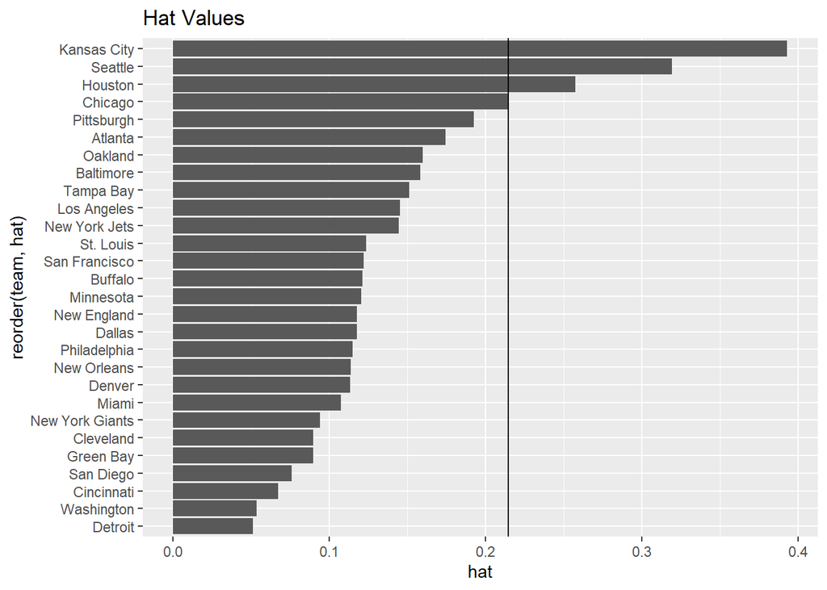

```r
football$hat <- hatvalues(lm)
ggplot(data = football, aes(x = reorder(team, hat), y = hat)) + geom_bar(stat = "identity") + geom_hline(yintercept = 2*3/28) + coord_flip() + ggtitle("Hat Values")
```

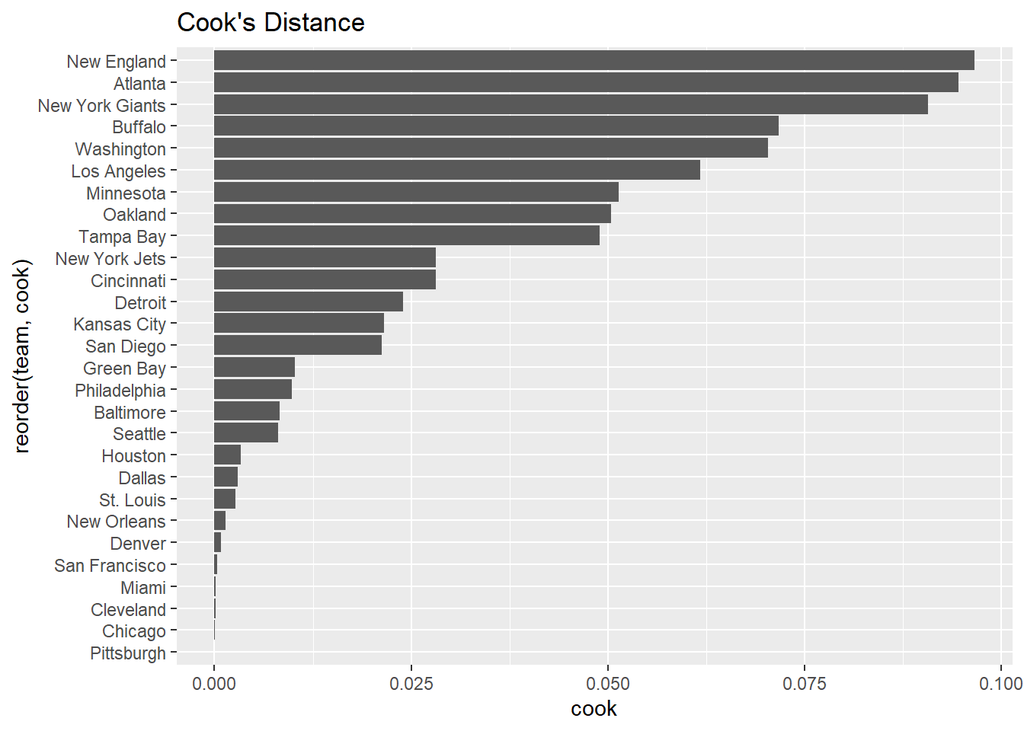

```r
football$cook <- cooks.distance(lm)
ggplot(data = football, aes(x = reorder(team, cook), y = cook)) + geom_bar(stat = "identity") + coord_flip() + ggtitle("Cook's Distance")
```

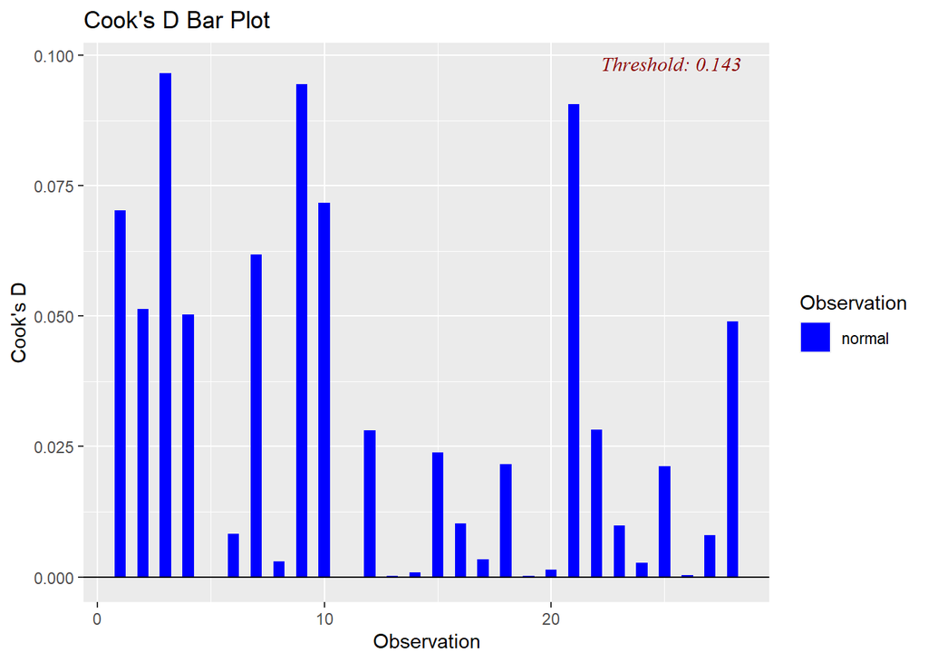

```r
ols_plot_cooksd_bar(lm)
```

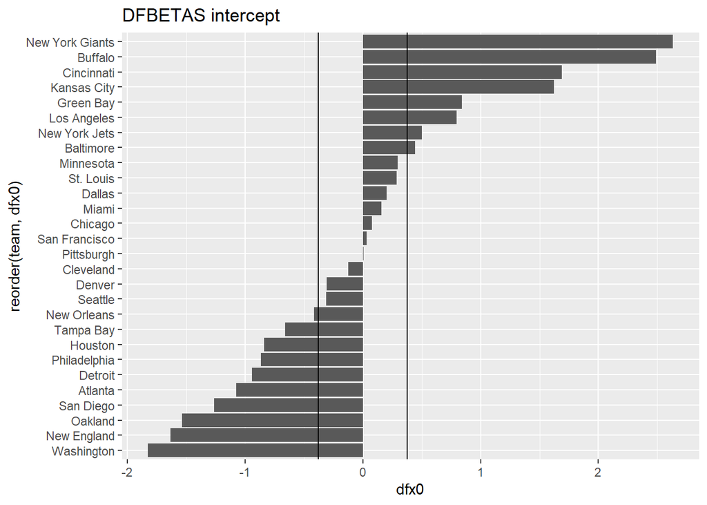

```r
ggplot(data = football, aes(x = reorder(team, dfx0), y = dfx0)) + geom_bar(stat = "identity") + coord_flip() + ggtitle("DFBETAS intercept") + geom_hline(yintercept = 2/sqrt(28)) + geom_hline(yintercept = -2/sqrt(28))
```

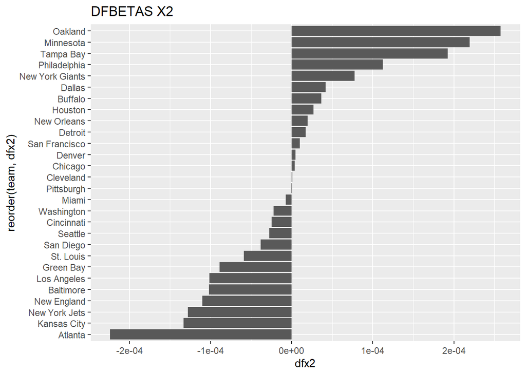

```r
ggplot(data = football, aes(x = reorder(team, dfx2), y = dfx2)) + geom_bar(stat = "identity") + coord_flip() + ggtitle("DFBETAS X2")
```

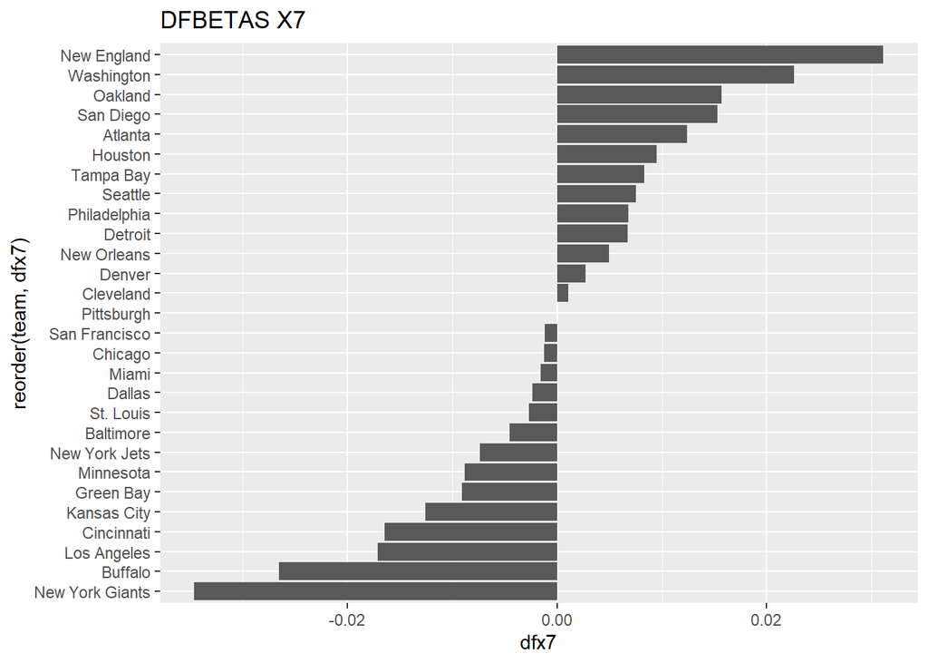

```r
ggplot(data = football, aes(x = reorder(team, dfx7), y = dfx7)) + geom_bar(stat = "identity") + coord_flip() + ggtitle("DFBETAS X7")
```

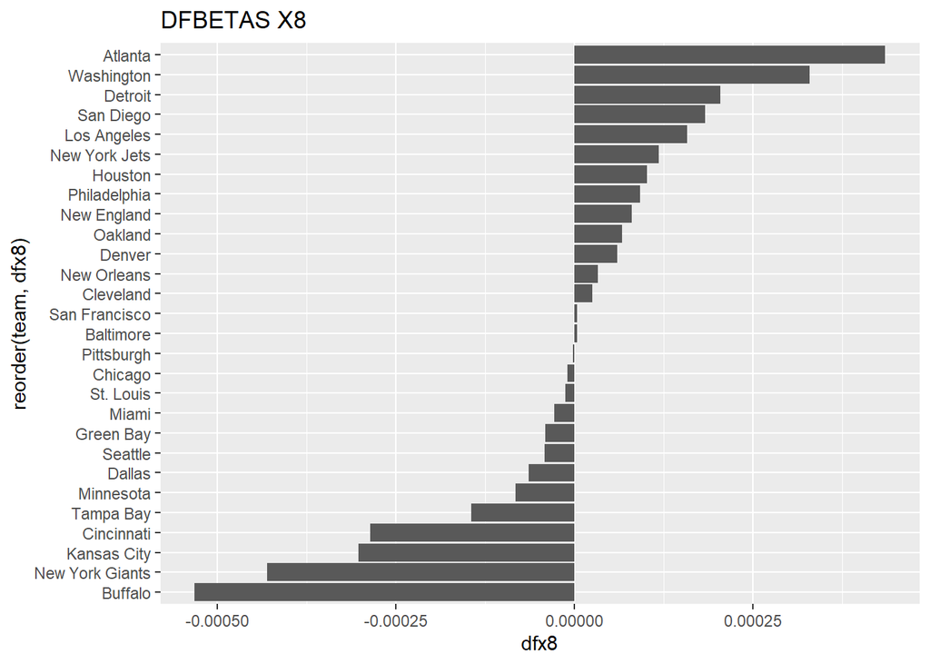

```r
ggplot(data = football, aes(x = reorder(team, dfx8), y = dfx8)) + geom_bar(stat = "identity") + coord_flip() + ggtitle("DFBETAS X8")
```

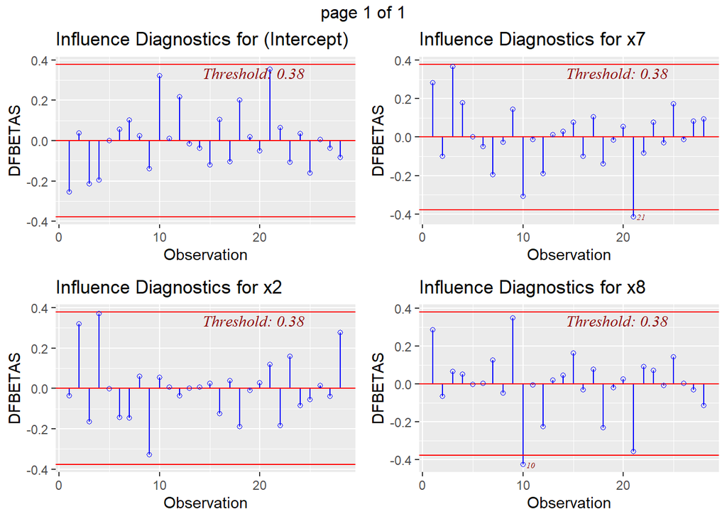

```r
ols_plot_dfbetas(lm)
```

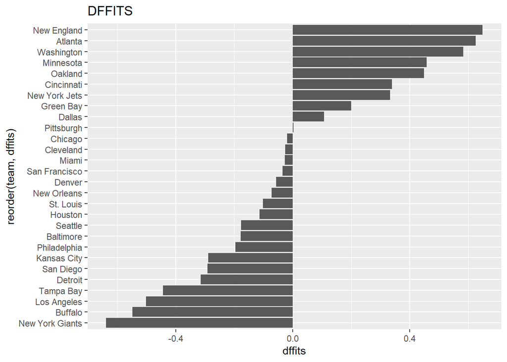

```r
football$dffits <- dffits(lm)
ggplot(data = football, aes(x = reorder(team, dffits), y = dffits)) + geom_bar(stat = "identity") + coord_flip() + ggtitle("DFFITS")
```

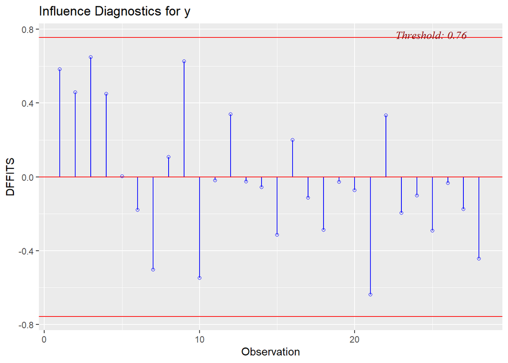

```r
ols_plot_dffits(lm)
```

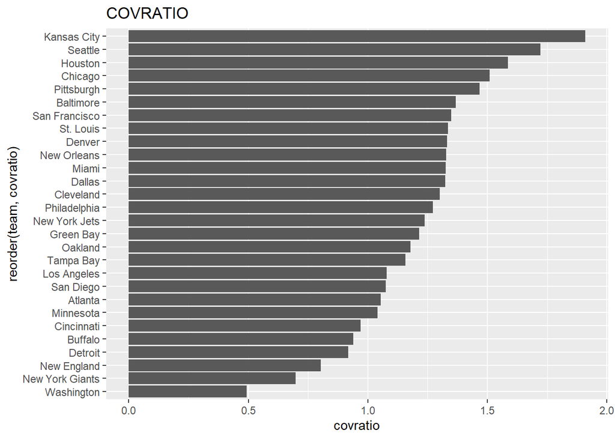

```r
football$covratio <- covratio(lm)
ggplot(data = football, aes(x = reorder(team, covratio), y = covratio)) + geom_bar(stat = "identity") + coord_flip() + ggtitle("COVRATIO")
```

We consider leverage/hat values greater than 2 times the number of predictors (3) divided by the sample size (28) to indicate high leverage observations. High leverage/hat observations are those with predictor values far from their averages, which greatly influence the model. Such points are Kansas City, Seattle, and Houston.

We consider points with Cook’s distance greater than or equal to one to be highly influential. None of our points have Cook’s distance greater than 0.1. That being said, Cook’s distance is greatest for New England, Atlanta, and the NY Giants, which suggests that these teams influence the model the most (albeit still not by a great amount). In other words, if you had to remove one team from the model, removing New England, Atlanta, or the NY Giants would alter the model much more than removing any other team, especially those with a very low Cook’s distance. The converse is also true; removing Cleveland, Chicago, and Pittsburgh would not alter the model as significantly.

3. Find the variance inflation factors and comment on multicollinearity in this model. (5 points)

```r
car::vif(lm)
```

```
##       x2       x7       x8
## 1.115977 2.097311 2.021254
```

A common rule of thumb for VIF is that a score greater than ten indicates high multicollinearity. As ours are all less than 2.1, none of our regression variables appear to be correlated.

4. Construct a normal probability plot of the residuals. Does there seem to be any problem with the normality assumption? (5 points)

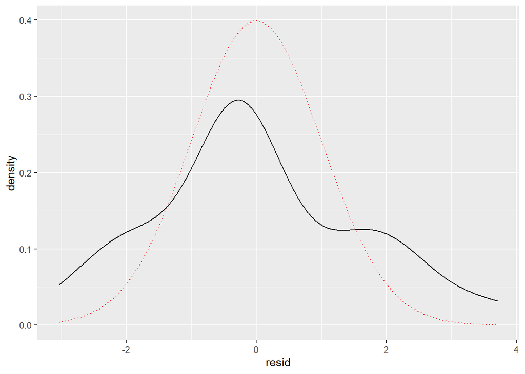

```r
football$resid <- resid(lm)
ggplot(football, aes(x = resid)) + geom_density(binwidth = 1.5) + stat_function(fun = function(n) dnorm(n, mean = 0, sd = 1), color = "red", linetype = "dotted")
```

```r
shapiro.test(football$resid)
```

```
##
##  Shapiro-Wilk normality test
##
## data:  football$resid
## W = 0.96508, p-value = 0.4566
```

There doesn’t appear to be a problem with the normality function. Additionally, the Shapiro-Wilk normality test agrees with this evaluation.

5. Construct and interpret a plot of the residuals versus the fitted values. (5 points)

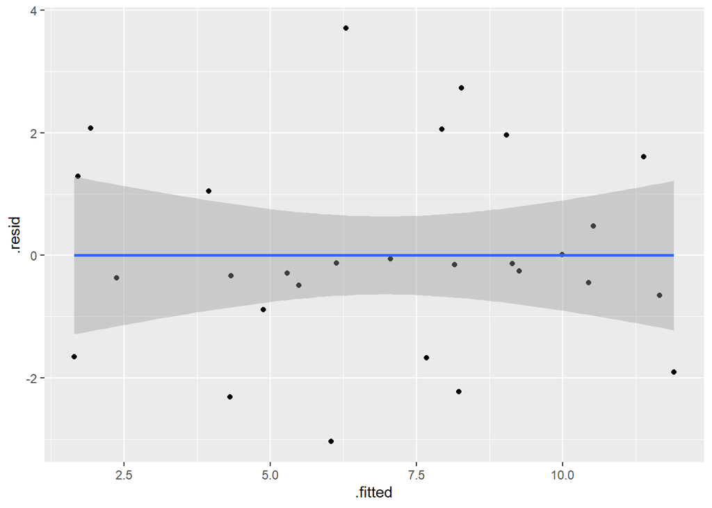

```r
ggplot(lm, aes(x = .fitted, y = .resid)) + geom_point() + geom_smooth(method = "lm")
```